# Repeated Interaction

with Connor T. Wiegand

## Previously

### Centipede Game

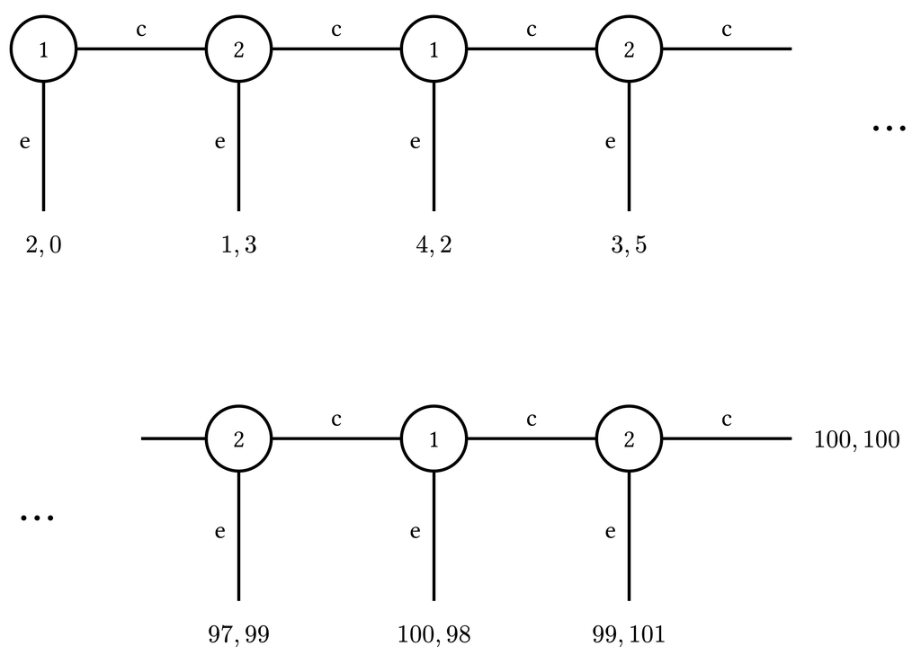

### Analysis

- At the end of the game, player 2 will end instead of continue to get an extra dollar
- Player 1 knows this, so they will end a round early for the extra dollar
- This line of thinking continues all the way back to the beginning of the game, where Backward Induction predicts that the game will end at the first stage
  - This is what we call **Unravelling**

## Repeated Games

### Recall: Prisoner’s Dilema

- Here, I am using *Cooperate*<sup>1</sup> and *Defect* as opposed to *Quiet* and *Snitch*

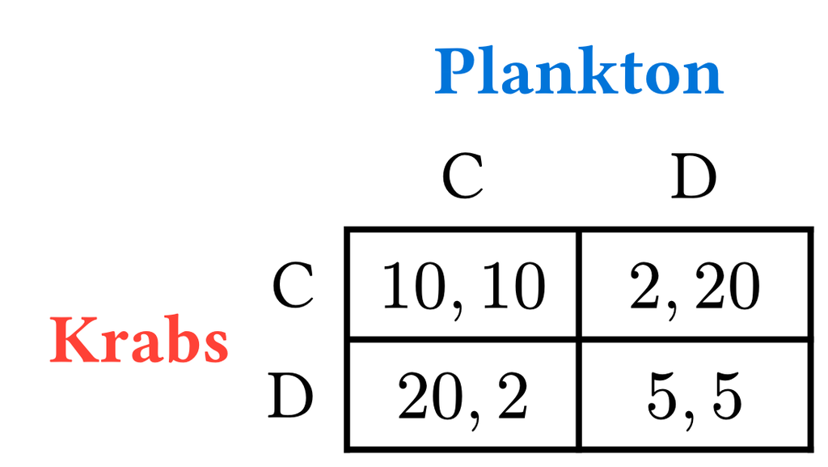

- **Question**
  - Can we *enforce*<sup>2</sup> the cooperative outcome, $(Q,Q)$, during repeated play?
[^1]: Cooperate with your partner, not with 12
[^2]: in a subgame-perfect sense

### Repeated PD

- Suppose we play PD 30 times
- The thought: on day 1, we know we have 29 more days of PD in front of us;
  - maybe we should try cooperating, using the remaining days as motivation to play the cooperative strategy
- Does this actually happen?
- Consider the following information-contingent plan of action:

  $$s=\begin{cases}
  \text{Play } C &\text{ if D has never been played before}\\
  \text{Play } D &\text{ if someone has played D before}
  \end{cases}$$

### Fact

- Using backward induction, it turns out that this incentive mechanism isn’t enough to pull us away from $(D,D)$, even on the first day
- As it turns out, finitely repeated games – especially those with non-changing stage games – are not that interesting
  - E.g., there isn’t some clever mechanism to enforce cooperation in a subgame-perfect sense
- What is this phenomenon called?
  - **Unravelling!**
  - This is also an application of the One-Shot Deviation Principle
    - Checking SPNE in finite multi-stage games typically amounts to checking for a deviation in a single stage game

## Infinitely repeated play

### Playing games forever

- How should we think about playing games forever?
- There are two stories we can tell which motivate infinite repeated play
  - They are *roughly* equivalent, less some differences in interpretation
  - One is easier to grasp and imagine
  - The other provides a more economically-portable interpretation
1. Game ends with fixed probability
2. Agents discount the future

### Game ends with fixed probability

- Let $\delta\in(0,1)$<sup>1</sup>
- Suppose that you are playing prisoner’s dilemma repeatedly
  - On day 0, you definitely play PD
  - On day 1, there is a $\delta$ probability that you play PD again, and a $1-\delta$ chance that the game is over…forever
  - Assuming the game didn’t end on day 1: On day 2, there is a $\delta$ probability that you play PD again, and a $1-\delta$ chance that the game is over
  - … (so on and so forth)
- This allows us to “simulate” infinite play
  - In theory, the game could go on forever
  - On the other hand, *math* tells us that this process will almost surely end at some point
- In particular, there is no “last stage” where our opponent will cheat us
[^3]: We may occasionally toss in the idea that delta could = 0 or 1

### Why would this change things?

- Think about $\delta$ being very small (e.g. close to 0):
  - When you play prisoner’s dilemma, there is a very small chance that you will see this person again
  - What should you do?
    - Probably cheat them; it’s not likely that this will have negative repercussions
- Now, think about $\delta$ being very large (close to 1):
  - Each time you play, there is a pretty good chance you will play them again tomorrow
  - So, you have more **incentive** to cooperate today, in hopes that this will lead to cooperation tomorrow

### Story 2: Discounting

- The other motivation for infinitely repeated assumes that agents *are* infinitely living
  - This is actually pretty common in econ: a decision you make frequently with no clear stopping point, a company, etc.
- However, the agents, much like you and I, like consumption today more than consumption tomorrow
  - Do you want $1 now, or $1.10 in 1 month?
  - $1 now or $2 in a month?
  - $5 in a month?
  - $10 in a month?

### Discounting, cont.

- Let’s assume the infinite-horizon agents discount the future at a constant factor of $\delta$
  - What is $\delta$?
- Suppose the interest rate is 25%: you would be indifferent between $1 now and $1.25 in the next **period**
  - If $r$ is the interest rate, then $\delta$ is given by
    $$\delta = \frac{1}{1+r}$$
  - In this example, $\delta=1/1.25=\frac{1}{5/4}=4/5=0.8$
  - What does that mean?
    - In this world suppose we asked “what is $1.25 received tomorrow worth today?”

### Discounting, cont.

- $r$ = 25%: indifferent between $1 now and $1.25 in the next period
  - If $r$ is the interest rate, then $\delta$ is given by
    $$\delta = \frac{1}{1+0.25}=0.8$$
- What does that mean?
  - In this world, suppose we asked “what is $1.25 received tomorrow worth today?”
  - $\delta$ is the discount factor is because it’s what we multiply ‘$1.25 tomorrow’ by to get it’s worth today
    - e.g.
      $$(\$1.25)\delta = \$1.25(0.8)=\$1$$
- I’m not too interested in [you] transforming the interest rate to the discount factor, so I might use “rate” interchangeably with “factor”

### What does this change?

- Now, we think of agents actually playing PD forever: they wake up each day<sup>1</sup> and play; it’s just a part of their every-day life
- However, these players prefer utility today over utility tomorrow
- Let’s think about a very low $\delta$ (close to 0)
  - This says that I care about future consumption much less than present consumption
  - Because of this, I might cheat you today in PD for a higher payoff, even though it means a possibly infinite future of low payoffs
- Now let’s think about a very high $\delta$ (close to 1)
  - $\delta = 1$ says I value consumption today just as much as consumption tomorrow
  - Since tomorrow’s utility is close to today’s, I no longer have a strong incentive to cheat my partner, as this would likely ruin our long-term relationship
[^4]: or *period*

### An Infinite Strategy

- What’s a strategy?
  - Information-contingent plan of action
- Let’s model information at a given stage of the game by $H$, which contains a history of all moves played thus far<sup>1</sup>
- Consider the following strategy:
  $$s_{GT} = \begin{cases}
  C & \text{if } D\notin H\\
  D & \text{otherwise}
  \end{cases}$$
- This says:
  - Try to cooperate (stay quiet) if no one has snitched before
  - If someone has defected (snitched) before, then defect again
- This stragey is aptly named **Grim Trigger**: if someone defects once, then we defect forever
  - This will be our primary focus going forward
[^5]: we are going to keep $H$ fairly non-technical, e.g. without rigorous definition, extracting intuition from it when needed

### What are we after?

- In general, with repeated games, we are interested in checking whether we can achieve a more pareto-efficient outcome, maintaining the assumption of sequential rationality
  - If we can: when?
    - e.g. what range of $\delta$ (using either interpretation) allows<sup>1</sup> this?
- For our discourse, we are interested in finding what values of $\delta$, if any, allow us to enforce the cooperative outcome in PD, using some particular strategy
  - This will limit our technical discussion to Grim Trigger, but we can discuss other commonly-studied strategies at some point
[^6]: moving forward, *admits*

## the good, the bad, the Mathy

### Reminder

- [This](https://www.mathsisfun.com/algebra/sequences-sums-geometric.html) is a very good reference
- Recall: if $x\neq 0$, then $x^{0}=1$

### Infinite Cake

Consider a cake

- I eat half the cake
  - You eat half of what’s left
    - e.g., a quarter of the whole cake
  - I then eat half of what’s left
    - e.g., an 1/8
  - Then, you eat half of what’s left
    - …
- How much did we eat?
  - On the one hand:
    $$\frac{1}{2} + \frac{1}{4} + \frac{1}{8} + \frac{1}{16} + \cdots$$
  - On the other hand: 1 whole cake

### Sigma Notation

- Consider a sequence of terms $x_{1}, x_{2}, \dots$
  - What are they? Just numbers
    - Often, they take the form $a \cdot x^{k}$, for some real number $a$, some $x\in(0,1)$, and some “natural” (counting) number $k$
- Then the *series* from $1$ to $k$ is a sum of the terms of this sequence, denoted by the following

  $$\sum_{k=1}^{n}x_{k}= x_{1} + x_{2} + x_3 + \cdots + x_{n}$$
- Consider $\{x_{k}\}=\left(\frac{1}{2}\right)^{k}$. We will often want to start at 0:

  $$\begin{aligned}
  \sum_{k=0}^{n}x_{k}&=\left(\frac{1}{2}\right)^{0} + \left(\frac{1}{2}\right)^{1} + \left(\frac{1}{2}\right)^{2} + \cdots + \left(\frac{1}{2}\right)^{n}\\
  &= 1 + \frac{1}{2} + \frac{1}{4}+\frac{1}{8} + \cdots + \frac{1}{2^n}
  \end{aligned}$$

### The geometric series

- Instead of ending at the $n^{\text{th}}$ term, we can even compute *infinite* sums
- We will primarily be focused on some flavor of the **geometric** series:
  $$\sum^{\infty} x^{n}$$
  - When $|x|<1$, we say the series *converges* to a value
  - When $|x|\geq 1$, we say the series *diverges*
- Here are some important sums to know; assume $|x| < 1$
- $$\sum_{k=0}^{\infty} x^{n} = \frac{1}{1-x}$$
- $$\sum_{k=1}^{\infty} x^{n} = \frac{x}{1-x}$$

### What if I can only remember one of those?

- No problem; use math to determine the other
- Suppose you know $\sum_{k=0}^{\infty} x^{n} = \frac{1}{1-x}$. Then

  $$\begin{aligned}
  \sum_{k=1}^{\infty} x^n &= \left(\sum_{k=0}^{\infty} x^{n}\right) - x^0\\
  &= \left(\frac{1}{1-x}\right) - 1\\
  &=\frac{1}{1-x} - \frac{1-x}{1-x}\\
  &=\frac{x}{1-x}
  \end{aligned}$$
- Intuition: If $x<1$, then $\frac{x}{1-x}$ will be smaller than $\frac{1}{1-x}$
  - So, $\frac{x}{1-x}$ is associated with the series which includes 1 less term

## Preview of next time

### GT

- Recall the so-called “Grim Trigger” strategy:
  $$s_{GT} = \begin{cases}
  C & \text{if } D\notin \mathcal{H}\\
  D & \text{otherwise}
  \end{cases}$$
- Let’s assume it’s day 1<sup>1</sup>, and, for simplicity, assume that your opponent is just playing $C$ all the time<sup>2</sup>
- What happens if you play $C$ all the time?

  $$\pi(\overline{C},\overline{C}) = 10 + 10\delta + 10 \delta^2 + 10 \delta^3 + \cdots$$
- From the POV of day 1, the prob. of getting to stage $k$ is $\delta^k$
- What is this payoff sum equal to?
[^7]: In fact, it’s equivalent assume it’s any day, and we have only cooperated thus far
[^8]: call this strategy $\overline{C}$

### Payoff of Infinite Cooperation

- Recall: $\delta\in(0,1)$
  $$\begin{aligned}
  \pi(\overline{C},\overline{C}) &= 10 + 10\delta + 10 \delta^2 + 10 \delta^3 + \cdots\\
  &= 10 (1 + \delta + \delta^2 + \delta^3 + \cdots)\\
  &= 10\sum_{k=0}^{\infty} \delta^k
  \end{aligned}$$
- It’s a geometric series!

$$\pi(\overline{C},\overline{C}) = 10\sum_{k=0}^{\infty} \delta^k = \frac{10}{1-\delta}$$

- In some classes, you might refer to this infinite stream of income using the term “present discounted value” (PDV)

### Payoff of Breaking Relationship

- Let’s consider another case: suppose I cheat you, but you don’t cheat me, on day 1, and then we defect every day thereafter
- Now what’s our PDV?
- $$\begin{aligned}
  \pi &= 20 + (5)\delta + (5) \delta^{2} + (5)\delta^3 + \cdots\\
  &= 20 + 5\sum_{k=1}^{\infty}\delta^{k}\\
  &= 20 + \frac{5\delta}{1-\delta}
  \end{aligned}$$
- Remark: if you can, please feel free to omit ones ($1$) when writing $1\cdot \delta$